# Game of thrones

4/22/2021

## Overview

## Story

Game of Thrones is a fantasy drama series, adapted from of A Song of Ice and Fire novels by George R. R. Martin

- **Seven Kingdoms** of Westeros with political conflicts to claim the Iron throne or fighting for independence
- The last descendant of the realm’s deposed ruling dynasty, plots a **return to the throne**
- The Night’s Watch, a military order defending the realm against **threats from the North** .

[figure not shown]

## The Opening

[video not shown]

## Quotes

“Winter is coming.” - Ned Stark  
“Any man who must say ‘I am the king’ is no true king.” - Tywin Lannister  
“All men must die, but we are not men.” - Daenerys Targaryen

## My favorite season

### Season 3

## Season 3 summary

*In King’s Landing, Tywin coerces Olenna into an agreement to marry Cersei to Loras. Cersei admits to Tyrion that Joffrey tried to have him killed during the siege. Tyrion informs Shae and Sansa about his and Sansa’s betrothal. Littlefinger tells Varys that he discovered Ros was Varys’ informant and that Joffrey killed her. In the Riverlands, Melisandre buys Gendry from the Brotherhood, and foretells Arya that she will kill many people with brown eyes, green eyes, and blue eyes; she promises they will meet again. Having married Talisa, Rob strikes a new agreement with Walder Frey by giving him Harrenhal and having his uncle, Edmure Tully, marry a Frey daughter or granddaughter. Roose Bolton plans to send Jaime to King’s Landing, but refuses to allow Brienne to accompany him. At an unknown location, the mysterious man continues torturing Theon. In the North, tension arises between Osha and Meera. Beyond the Wall, Sam continues his flight with Gilly, while Jon and Ygritte scale the Wall with two other Wildlings.*

## Season’s viewership

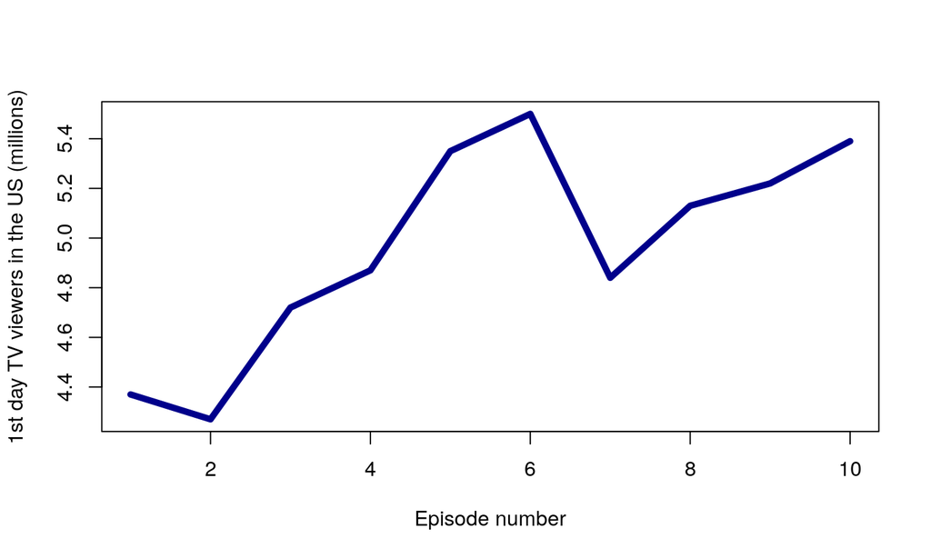

## Keywords

Episodes with the word fire in the description were:

|  | No. in season | Title | Number of viewers |
| --- | --- | --- | --- |
| 9 | 5 | “Kissed by Fire” | 5.35 |
| 15 | 8 | “Second Sons” | 5.13 |